# Proyecto 1 CDE

Tomás Cantuarias - Raimundo Moraga - Victor Valero

2022-04-22

## Introducción

Dentro de Chile, existen varios tipos de fenómenos geológicos, ya que existen una gran cantidad de montañas, lagos, ríos, playas y puertos. Pero además de estos, existen **glaciares**, que son grandes áreas congeladas, creadas gracias a las bajas temperaturas que se encuentran en las zonas sur del país mayoritariamente. Estos serán los objetos principales de estudio en este informe.

El objetivo de este estudio será poder analizar las áreas de los distintos glaciares existentes en Chile y las ciudades más cercanas a estos, y poder demostrar que los glaciares con áreas mayores tienden a tener una mayor cantidad de ciudades cercanas que aquellos que tienen menores áreas.

## Metodología

Para poder demostrar esto, se hará uso de la librería **RNaturalEarth** para conseguir las posiciones de los glaciares, utilizando un enfoque para solamente analizar los glaciares que existen en Chile. Esto se hace aplicando un filtro que intersecte un conjunto de datos que contiene las distintas ciudades de Chile, con el conjunto de datos que incluye todos los glaciares del mundo. Al aplicar esto, se consigue que existen 70 glaciares alrededor de todo Chile. Si bien se logra conseguir la información de los distintos glaciares de Chile, no se logra conseguir los nombres de estos gracias a que la librería tiene data incompleta, por lo cual se ignora el nombre de estos para términos de análisis. Además, se confirma esta data gracias a la información entregada por (“Inventario de Glaciares Chile - Camara.cl,” n.d.).

Luego de esto, se hace un mapa que muestre los glaciares de chile (Ver gráfico 1).

[interactive chart not shown]

Figure 1: Mapa glaciares

## Datos

Luego de filtrar los glaciares Chilenos, y conseguir las áreas de estos, se pueden resumir en la tabla 1:

Table 1: 15 mayores áreas

| Área |
| --- |
| 13,087.44 [km^2] |
| 3,917.99 [km^2] |
| 1,612.79 [km^2] |
| 842.55 [km^2] |
| 826.88 [km^2] |
| 544.62 [km^2] |
| 476.76 [km^2] |
| 365.74 [km^2] |
| 358.54 [km^2] |
| 339.49 [km^2] |
| 333.47 [km^2] |
| 251.07 [km^2] |
| 230.14 [km^2] |
| 229.14 [km^2] |
| 216.95 [km^2] |

Si bien se encuentran solamente los 15 glaciares con mayores áreas, se puede encontrar la tabla entera en la sección de anexos. Luego de esto se procede a analizar la distancia de los glaciares con las ciudades, para poder relacionar cada glaciar con una ciudad.

Para realizar este análisis, se procedió a tomar una distancia Haversine entre cada glaciar y todas las ciudades, para luego aplicar un criterio de distancia para de esta manera proceder a definir qué distancia cumplía con el criterio de estar “cerca” al glaciar y cuáles no. Este umbral fué determinado como **menor o igual a 200 [km]** Y de esta manera poder determinar la cantidad de ciudades que se encuentren a menos de 200 [km] de un glaciar.

Con este criterio, se logró crear la tabla 2 que muestra los glaciares y las ciudades que estaban cerca de estos.

Table 2: 15 glaciares mayores con ciudades cercanas

| Glaciar | Cantidad de ciudades cercanas |
| --- | --- |
| 13087.44 [km^2] | 1 |
| 3917.99 [km^2] | 4 |
| 1612.79 [km^2] | 2 |
| 842.55 [km^2] | 7 |
| 826.88 [km^2] | 1 |
| 544.62 [km^2] | 6 |
| 476.76 [km^2] | 2 |
| 365.74 [km^2] | 8 |
| 358.54 [km^2] | 6 |
| 339.49 [km^2] | 11 |
| 333.47 [km^2] | 4 |
| 251.07 [km^2] | 8 |
| 230.14 [km^2] | 11 |
| 229.14 [km^2] | 1 |
| 216.95 [km^2] | 3 |

Viendo esta tabla (tabla completa se encuentra anexos), se puede analizar la cantidad de ciudades que existen cerca de estos glaciares, en donde se ve que el mayor número de ciudades cercanas es **14** (revisar tabla 4), pero este glaciar no se encuentra nisiquiera entre los 15 con mayores áreas. Por otro lado, se puede ver que el glaciar con máyor área solamente tiene 1 ciudad cercana, que en esta caso sería **Villa O’Higgins**. Esto se puede dar gracias a que el glaciar se encuentra en la zona sur patagónica del país, por lo que no existen muchos lugares poblados por ese sector, dadas las condiciones atmosféricas del sur Chileno. Si bien revisando la tabla se puede ver que la hipótesis inicial de que a mayor área del glaciar, una mayor cantidad de ciudades cercanas no se cumple, se puede revisar un gráfico de correlación para poder revisar la correlación entre estas dos variables.

Revisar gráfico 2.

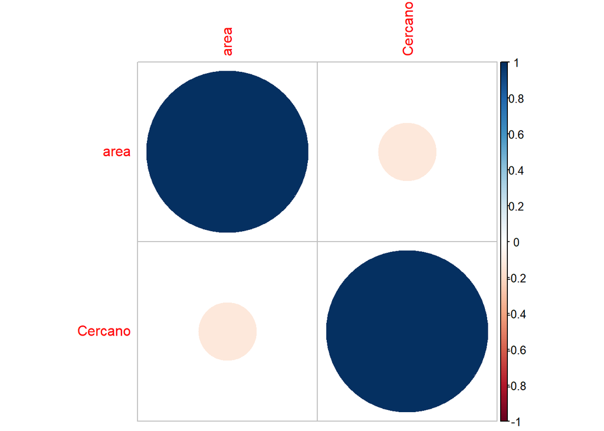

Figure 2: Correlación área de glaciares vs cantidad de ciudades cercanas

|  | area | Cercano |
| --- | --- | --- |
| area | 1.0000000 | -0.1281189 |
| Cercano | -0.1281189 | 1.0000000 |

Con esto se puede ver que existe una baja correlación entre estas dos variables, teniendo un valor de **-0.128** por lo cual no existe una correlación significante entre estos datos, Concluyendo que la hipótesis inicial es falsa.

A modo de conclusión, se puede ver que al inspeccionar los glaciares, la localización de estos importa más que el área de estos al momento de poder determinar la cantidad de ciudades que se encuentren cercanas a este. Si bien el glaciar más grande tiene un área bastante mayor al que tiene una mayor cantidad de ciudades cercanas, el primero se encuentra en un área patagónica que tiene una densidad poblacional bastante baja dada las condiciones de vida que existen en ese sector (gracias al clima, cercanía con el resto del país, entre otros factores) mientras que el segundo se encuentra en la zona norte del país, donde existen más ciudades que en la zona sur.

## Bibliografía

“Inventario de Glaciares Chile - Camara.cl.” n.d. *Camara.cl*. https://www.camara.cl/verDoc.aspx?prmTIPO=DOCUMENTOCOMUNICACIONCUENTA&prmID=14323.

## Anexos

Table 3: Áreas glaciares

| Área |
| --- |
| 13,087.44 [km^2] |
| 3,917.99 [km^2] |
| 1,612.79 [km^2] |
| 842.55 [km^2] |
| 826.88 [km^2] |
| 544.62 [km^2] |
| 476.76 [km^2] |
| 365.74 [km^2] |
| 358.54 [km^2] |
| 339.49 [km^2] |
| 333.47 [km^2] |
| 251.07 [km^2] |
| 230.14 [km^2] |
| 229.14 [km^2] |
| 216.95 [km^2] |
| 201.91 [km^2] |
| 200.96 [km^2] |
| 189.84 [km^2] |
| 184.44 [km^2] |
| 166.23 [km^2] |
| 161.43 [km^2] |
| 152.66 [km^2] |
| 147.84 [km^2] |
| 142.48 [km^2] |
| 138.27 [km^2] |
| 114.03 [km^2] |
| 113.24 [km^2] |
| 102.72 [km^2] |
| 97.26 [km^2] |
| 90.60 [km^2] |
| 90.15 [km^2] |
| 87.69 [km^2] |
| 86.74 [km^2] |
| 85.80 [km^2] |
| 82.76 [km^2] |
| 81.20 [km^2] |
| 80.93 [km^2] |
| 80.86 [km^2] |
| 74.52 [km^2] |
| 71.66 [km^2] |
| 69.06 [km^2] |
| 66.85 [km^2] |
| 64.27 [km^2] |
| 56.85 [km^2] |
| 56.74 [km^2] |
| 56.45 [km^2] |
| 56.43 [km^2] |
| 54.88 [km^2] |
| 53.84 [km^2] |
| 53.11 [km^2] |
| 49.95 [km^2] |
| 47.96 [km^2] |
| 45.31 [km^2] |
| 44.66 [km^2] |
| 42.87 [km^2] |
| 42.80 [km^2] |
| 40.98 [km^2] |
| 39.22 [km^2] |
| 39.14 [km^2] |
| 38.63 [km^2] |
| 38.43 [km^2] |
| 37.65 [km^2] |
| 37.19 [km^2] |
| 34.99 [km^2] |
| 32.55 [km^2] |
| 30.67 [km^2] |
| 2.85 [km^2] |
| 0.04 [km^2] |
| 0.01 [km^2] |
| 0.00 [km^2] |

Table 4: Glaciares con ciudades cercanas

| Glaciar | Cantidad de Ciudades |
| --- | --- |
| 86.74 [km^2] | 14 |
| 56.74 [km^2] | 12 |
| 339.49 [km^2] | 11 |
| 230.14 [km^2] | 11 |
| 200.96 [km^2] | 10 |
| 147.84 [km^2] | 9 |
| 0.01 [km^2] | 9 |
| 365.74 [km^2] | 8 |
| 251.07 [km^2] | 8 |
| 81.20 [km^2] | 8 |
| 0.04 [km^2] | 8 |
| 842.55 [km^2] | 7 |
| 152.66 [km^2] | 7 |
| 74.52 [km^2] | 7 |
| 64.27 [km^2] | 7 |
| 53.11 [km^2] | 7 |
| 544.62 [km^2] | 6 |
| 358.54 [km^2] | 6 |
| 201.91 [km^2] | 6 |
| 189.84 [km^2] | 6 |
| 82.76 [km^2] | 6 |
| 37.65 [km^2] | 6 |
| 56.85 [km^2] | 5 |
| 3917.99 [km^2] | 4 |
| 333.47 [km^2] | 4 |
| 113.24 [km^2] | 4 |
| 102.72 [km^2] | 4 |
| 85.80 [km^2] | 4 |
| 69.06 [km^2] | 4 |
| 56.43 [km^2] | 4 |
| 53.84 [km^2] | 4 |
| 47.96 [km^2] | 4 |
| 39.22 [km^2] | 4 |
| 34.99 [km^2] | 4 |
| 216.95 [km^2] | 3 |
| 161.43 [km^2] | 3 |
| 138.27 [km^2] | 3 |
| 114.03 [km^2] | 3 |
| 71.66 [km^2] | 3 |
| 45.31 [km^2] | 3 |
| 42.87 [km^2] | 3 |
| 38.63 [km^2] | 3 |
| 30.67 [km^2] | 3 |
| 1612.79 [km^2] | 2 |
| 476.76 [km^2] | 2 |
| 142.48 [km^2] | 2 |
| 97.26 [km^2] | 2 |
| 90.60 [km^2] | 2 |
| 90.15 [km^2] | 2 |
| 87.69 [km^2] | 2 |
| 80.93 [km^2] | 2 |
| 80.86 [km^2] | 2 |
| 66.85 [km^2] | 2 |
| 56.45 [km^2] | 2 |
| 54.88 [km^2] | 2 |
| 49.95 [km^2] | 2 |
| 44.66 [km^2] | 2 |
| 42.80 [km^2] | 2 |
| 40.98 [km^2] | 2 |
| 38.43 [km^2] | 2 |
| 37.19 [km^2] | 2 |
| 32.55 [km^2] | 2 |
| 0.00 [km^2] | 2 |
| 13087.44 [km^2] | 1 |
| 826.88 [km^2] | 1 |
| 229.14 [km^2] | 1 |
| 184.44 [km^2] | 1 |
| 166.23 [km^2] | 1 |
| 39.14 [km^2] | 1 |
| 2.85 [km^2] | 1 |